# PS5-rmarkdown and plotting

Liu Yuliang

2/19/2023

# Instructions

This is a problem set about rmarkdown and plotting (using ggplot). Unlike the previous problem sets, this one does not give you a ready-made GH repo with a code file–it is now your task to create a repo and include your rmarkdown file in there.

You should answer the questions below in that file, knit it, and submit both the compiled html and link to your repo on canvas.

- This problem sets asks you to write extensively when commenting your results. Please write clearly! Answer questions in a way that if the code chunks are hidden then the result is still readable!
  - All substantial questions need explanations. You do not have to explain the simple things like “how many rows are there in data”, but if you make a plot of life expectancy, then you should explain what does the plot tell you.
  - Write explanations as markdown and use the styles like bold and italic as appropriate.
- Do not print too much results. It is all well to print a few lines of data for evaluation/demonstration purposes. But do not print dozens (or thousands!) of lines–no one bothers to look at that many numbers. You will lose points for annoying others (here your graders, but later potentially your boss).
- Do not make code lines too long. 80-100 characters is a good choice. Your grader may not be able to follow all the code if the line is too long–most of us are using small laptop screens! (And again–you want to keep your graders happy!)

# Gapminder data

We use gapminder dataset, downloaded from [**https://www.gapminder.org/data/**](https://www.gapminder.org/data/), however, the data structure there is quire complex, please use the dataset provided on canvas (in files/data).  
The variables are:  
**name** country name  
**iso3** 3-letter country code  
**iso2** 2-letter country code  
**region** broad geographic region  
**sub-region** more precise region  
**intermediate-region**  
**time** year  
**totalPopulation** total population  
**GDP_PC** GDP per capita (constant 2010 US$)  
**accessElectricity** Access to electricity (% of population)  
**agriculturalLand** Agricultural land (sq. km)  
**agricultureTractors** Agricultural machinery, tractors (count)  
**cerealProduction** Cereal production (metric tons)  
**feritilizerHa** Fertilizer consumption (kilograms per hectare of arable land)  
**fertilityRate** total fertility rate (births per woman)  
**lifeExpectancy** Life expectancy at birth, total (years)  
**childMortality** Mortality rate, under-5 (per 1,000 live births)  
**youthFemaleLiteracy** Literacy rate, youth female (% of females ages 15-24)  
**youthMaleLiteracy** Literacy rate, youth male (% of males ages 15-24)  
**adultLiteracy** Literacy rate, adult total (% of people ages 15 and above)  
**co2** CO2 emissions (kt)  
**greenhouseGases** Total greenhouse gas emissions (kt of CO2 equivalent)  
**co2_PC** CO2 emissions (metric tons per capita)  
**pm2.5_35** PM2.5 pollution, population exposed to levels exceeding WHO Interim Target-1 value 36ug/m3  
**battleDeaths** Battle-related deaths (number of people)

# 1 Load and check data (5pt)

You first task is to do a very simple data check:

1. (1pt) For solving the problems, and answering the questions, create a new rmarkdown document with an appropriate title. See [**https://faculty.washington.edu/otoomet/info201-book/r-markdown.html#r-markdown-rstudio-creating**](https://faculty.washington.edu/otoomet/info201-book/r-markdown.html#r-markdown-rstudio-creating).

```r
gapminder <- read_delim("gapminder.csv")
```

2. (2pt) Load data. How many rows/columns do we have?

```r
num_of_rows <- nrow(gapminder)
num_of_rows
```

```
## [1] 13055
```

```r
num_of_cols <- ncol(gapminder)
num_of_cols
```

```
## [1] 25
```

3. (2pt) Print a small sample of data. Does it look OK?

```r
gapminder %>%
  head(5)
```

```
## # A tibble: 5 × 25
##   iso3  name  iso2  region sub-r…¹ inter…²  time total…³ ferti…⁴ lifeE…⁵ child…⁶
##   <chr> <chr> <chr> <chr>  <chr>   <chr>   <dbl>   <dbl>   <dbl>   <dbl>   <dbl>
## 1 ABW   Aruba AW    Ameri… Latin … Caribb…  1960   54211    4.82    65.7      NA
## 2 ABW   Aruba AW    Ameri… Latin … Caribb…  1961   55438    4.66    66.1      NA
## 3 ABW   Aruba AW    Ameri… Latin … Caribb…  1962   56225    4.47    66.4      NA
## 4 ABW   Aruba AW    Ameri… Latin … Caribb…  1963   56695    4.27    66.8      NA
## 5 ABW   Aruba AW    Ameri… Latin … Caribb…  1964   57032    4.06    67.1      NA
## # … with 14 more variables: youthFemaleLiteracy <dbl>, youthMaleLiteracy <dbl>,
## #   adultLiteracy <dbl>, GDP_PC <dbl>, accessElectricity <dbl>,
## #   agriculturalLand <dbl>, agricultureTractors <dbl>, cerealProduction <dbl>,
## #   fertilizerHa <dbl>, co2 <dbl>, greenhouseGases <dbl>, co2_PC <dbl>,
## #   pm2.5_35 <dbl>, battleDeaths <dbl>, and abbreviated variable names
## #   ¹`sub-region`, ²`intermediate-region`, ³totalPopulation, ⁴fertilityRate,
## #   ⁵lifeExpectancy, ⁶childMortality
```

The data looks good, although there are many NA values.

# 2 Descriptive statistics (15pt)

1. (3pt) How many countries are there in the dataset? Analyze all three: *iso3*, *iso2* and *name*.

```r
iso3_count <- length(unique(gapminder$iso3))
iso2_count <- length(unique(gapminder$iso2))
name_count <- length(unique(gapminder$name))
iso3_count
```

```
## [1] 253
```

```r
iso2_count
```

```
## [1] 249
```

```r
name_count
```

```
## [1] 250
```

There are 253, 249 and 250 countries in iso3, iso2 and name, respectively.

2. If you did this correctly, you saw that there are more iso-2 codes than names, and there are even more *iso3*-codes. What is going on? Can you find it out?
   1. (5pt) Find how many names are there for each iso-2 code. Are there any iso-2 codes that correspond to more than one name? What are these countries?

```r
multi_name_iso2 <- gapminder %>%
  filter(is.na(iso3) & is.na(name)) %>%
  group_by(iso2) %>%
  summarize(distinct_name = n_distinct(iso2)) %>%
  print()
```

```
## # A tibble: 0 × 2
## # … with 2 variables: iso2 <chr>, distinct_name <int>
```

There is no iso-2 codes that correspond to more than one name.

```
(b) (5pt) Now repeat the same for name and iso3-code. Are there country names that have more than one iso3-code? What are these countries? Hint: two of these entitites are *CHANISL* and *NLD CURACAO*.
```

```r
multi_name_name <- gapminder %>%
  filter(is.na(iso2) & is.na(iso3)) %>%
  group_by(name) %>%
  summarize(distinct_name = n_distinct(name)) %>%
  print()
```

```
## # A tibble: 0 × 2
## # … with 2 variables: name <chr>, distinct_name <int>
```

```r
multi_name_iso3 <- gapminder %>%
  filter(is.na(iso2) & is.na(name)) %>%
  group_by(iso3) %>%
  summarize(distinct_name = n_distinct(iso3)) %>%
  print()
```

```
## # A tibble: 4 × 2
##   iso3        distinct_name
##   <chr>               <int>
## 1 CHANISL                 1
## 2 GBM                     1
## 3 KOS                     1
## 4 NLD_CURACAO             1
```

There are 4 countries that have more than one iso3-code, which are CHANISL, GBM, KOS and NLD_CURACAO.

3. (2pt) What is the minimum and maximum year in these data?

```r
min_year <- gapminder %>%
  filter(!is.na(time)) %>%
  summarize(min_year = min(time)) %>%
  print()
```

```
## # A tibble: 1 × 1
##   min_year
##      <dbl>
## 1     1960
```

```r
max_year <- gapminder %>%
  filter(!is.na(time)) %>%
  summarize(max_year = max(time)) %>%
  print()
```

```
## # A tibble: 1 × 1
##   max_year
##      <dbl>
## 1     2019
```

# 3 CO2 emissions (30pt)

Next, let’s analyze CO2 emissions.

1. (2pt) How many missing co2 emissions are there for each year? Analyze both missing *CO2* and *co2_PC*. Which years have most missing data?

```r
missing_co2 <- gapminder %>%
  filter(!is.na(time)) %>%
  group_by(time) %>%
  summarize(missing_co2 = sum(is.na(co2))) %>%
  arrange(desc(missing_co2))

show_missing_co2 <- missing_co2 %>%
  head() %>%
  print()
```

```
## # A tibble: 6 × 2
##    time missing_co2
##   <dbl>       <int>
## 1  2017         217
## 2  2018         217
## 3  2019         217
## 4  1960          60
## 5  1961          60
## 6  1962          58
```

```r
missing_co2_PC <- gapminder %>%
  filter(!is.na(time)) %>%
  group_by(time) %>%
  summarize(missing_co2_PC = sum(is.na(co2_PC))) %>%
  arrange(desc(missing_co2_PC))
show_missing_co2_PC <- missing_co2_PC %>%
  head() %>%
  print()
```

```
## # A tibble: 6 × 2
##    time missing_co2_PC
##   <dbl>          <int>
## 1  2017            217
## 2  2018            217
## 3  2019            217
## 4  1960             60
## 5  1961             60
## 6  1962             58
```

Year 2017, 2018 and 2019 have the most missing data that count for 217 NA values.

2. (5pt) Make a plot of total CO2 emissions over time for the U.S, China, and India. Add a few more countries of your choice. Explain what do you see.

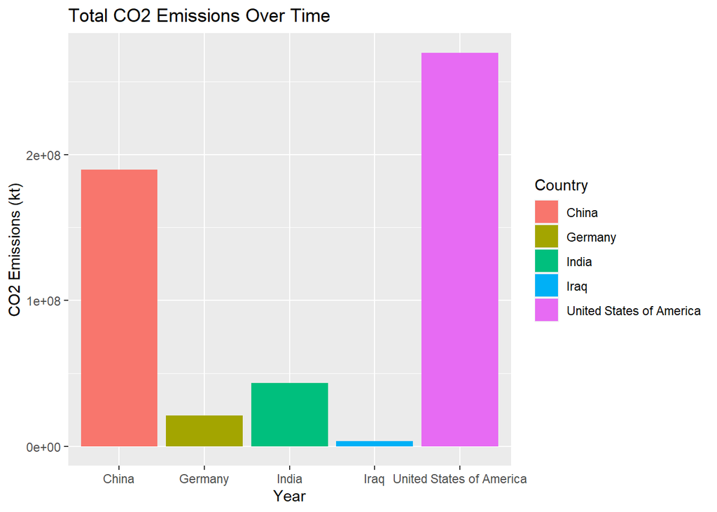

```r
filter_countries_co2 <- gapminder %>%
  filter(name == "United States of America" | name == "China" | name == "India"
         | name == "Germany" | name == "Iraq") %>%
  filter(!is.na(co2))

ggplot(filter_countries_co2, aes(x = name, y = co2, fill = name)) +
  geom_col() +
  labs(title = "Total CO2 Emissions Over Time",
       x = "Year",
       y = "CO2 Emissions (kt)",
       fill = "Country")
```

United States of America has the most CO2 emissions, coming by China as the second place. Iraq has the least CO2 emissions.

3. (5pt) Now let’s analyze the CO2 emissions per capita (*co2_PC*). Make a similar plot of thesame countries. What does this figure suggest?

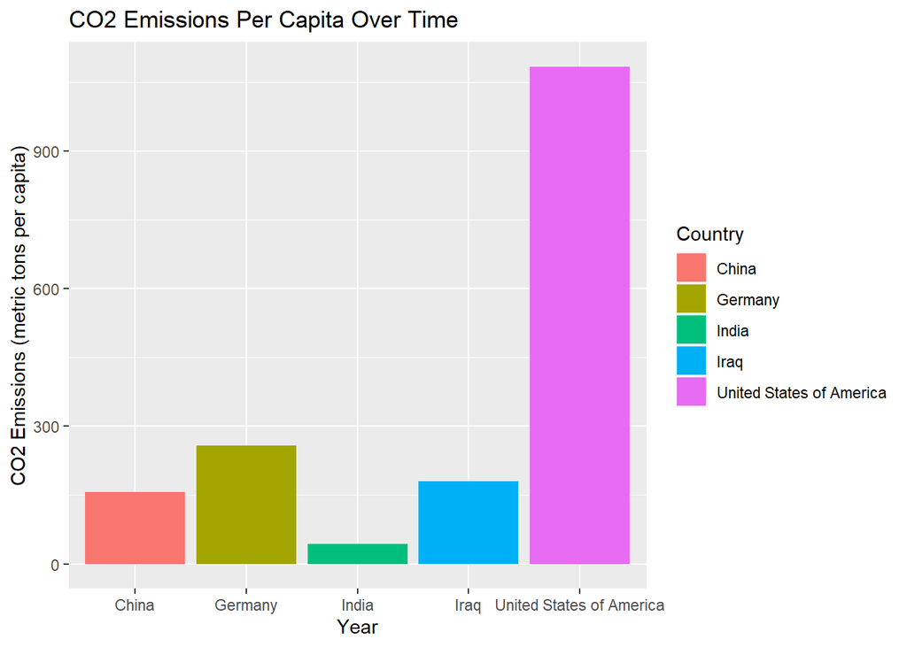

```r
filter_countries_co2_pc <- gapminder %>%
  filter(name == "United States of America" | name == "China" | name == "India"
         | name == "Germany" | name == "Iraq") %>%
  filter(!is.na(co2_PC))

ggplot(filter_countries_co2_pc, aes(x = name, y = co2_PC, fill = name)) +
  geom_col() +
  labs(title = "CO2 Emissions Per Capita Over Time",
       x = "Year",
       y = "CO2 Emissions (metric tons per capita)",
       fill = "Country")
```

4. (6pt) Compute average CO2 emissions per capita across the continents (assume *region* is the same as continent). Comment what do you see.  
   Note: just compute averages over countries and ignore the fact that countries are of different size.  
   Hint: Americas 2016 should be 4.80.

```r
overall_avg_co2 <- gapminder %>%
  filter(!is.na(co2_PC) & !is.na(region)) %>%
  group_by(region) %>%
  summarize(overall_avg_co2 = mean(co2_PC, na.rm = TRUE)) %>%
  print()
```

```
## # A tibble: 5 × 2
##   region   overall_avg_co2
##   <chr>              <dbl>
## 1 Africa             0.930
## 2 Americas           6.46
## 3 Asia               6.21
## 4 Europe             7.95
## 5 Oceania            4.39
```

```r
avg_co2_in_1960_and_2016 <- gapminder %>%
  filter(!is.na(co2_PC) & !is.na(region)) %>%
  filter(time == 1960 | time == 2016) %>%
  group_by(region, time) %>%
  summarize(avg_co2 = mean(co2_PC, na.rm = TRUE)) %>%
  print()
```

```
## # A tibble: 10 × 3
## # Groups:   region [5]
##    region    time avg_co2
##    <chr>    <dbl>   <dbl>
##  1 Africa    1960   0.291
##  2 Africa    2016   1.20
##  3 Americas  1960   7.15
##  4 Americas  2016   4.80
##  5 Asia      1960   1.74
##  6 Asia      2016   6.47
##  7 Europe    1960   5.77
##  8 Europe    2016   6.64
##  9 Oceania   1960   2.73
## 10 Oceania   2016   4.57
```

5. (7pt) Make a barplot where you show the previous results–average CO2 emissions per capita across continents in 1960 and 2016.  
   Hint: it should look something along these lines(**Please refer to the spec for the graph**)

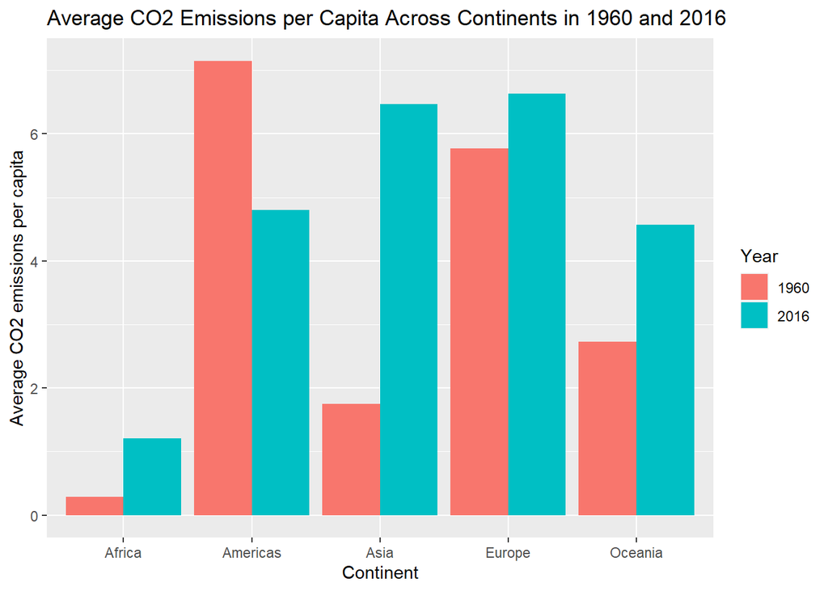

```r
ggplot(avg_co2_in_1960_and_2016, aes(x = region, y = avg_co2, fill = factor(time))) +
  geom_bar(stat = "identity", position = "dodge") +
  labs(x = "Continent", y = "Average CO2 emissions per capita", fill = "Year") +
  ggtitle("Average CO2 Emissions per Capita Across Continents in 1960 and 2016")
```

The barplot shows the average CO2 emissions per capita across continents in 1960 and 2016.

6. Which countries are the three largest, and three smallest CO2 emitters (in terms of CO2 per capita) in 2019 for each continent? (Assume *region* is continent).

```r
top_co2_2019 <- gapminder %>%
  filter(time == 2019) %>%
  filter(!is.na(region)) %>%
  group_by(region, name) %>%
  summarize(mean_co2_PC = mean(co2_PC)) %>%
  arrange(region, desc(mean_co2_PC)) %>%
  top_n(3) %>%
  print()
```

```
## # A tibble: 0 × 3
## # Groups:   region [0]
## # … with 3 variables: region <chr>, name <chr>, mean_co2_PC <dbl>
```

```r
bot_co2_2019 <- gapminder %>%
  filter(time == 2019) %>%
  filter(!is.na(region)) %>%
  group_by(region, name) %>%
  summarize(mean_co2_PC = mean(co2_PC)) %>%
  arrange(region, mean_co2_PC) %>%
  top_n(3) %>%
  print()
```

```
## # A tibble: 0 × 3
## # Groups:   region [0]
## # … with 3 variables: region <chr>, name <chr>, mean_co2_PC <dbl>
```

Since the data of CO2 per capita are missing in all 2019 year (all NA values), the sorting of three largest and smallest CO2 emitters therefore yield no output.

# 4 GDP per capita (50pt)

Let’s look at GDP per capita (*GDP_PC*)

1. (8pt) Make a scatterplot of GDP per capita versus life expectancy by country, using data for 1960. Make the point size dependent on the country size, and color those according to the continent. Feel free to adjust the plot in other ways to make it better.  
   Comment what do you see there.

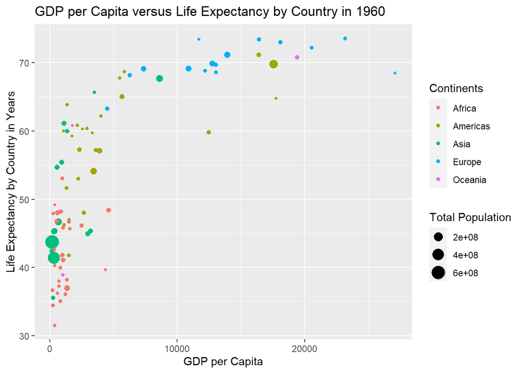

```r
data_1960 <- gapminder %>%
  filter(time == 1960) %>%
  filter(!is.na(GDP_PC) & !is.na(lifeExpectancy))

ggplot(data_1960, aes(x = GDP_PC, y = lifeExpectancy, size = totalPopulation)) +
    geom_point(aes(color = region)) +
    labs(x = "GDP per Capita", y = "Life Expectancy by Country in Years",
         color = "Continents", size = "Total Population") +
    ggtitle("GDP per Capita versus Life Expectancy by Country in 1960")
```

Wealthier continents, like Americas, Europe and Oceania had a higher GDP per capita, and a higher life expectancy. On the other hand, developing countries normally had lower than 60 years of life expectancy.

2. (4pt) Make a similar plot, but this time use 2019 data only.

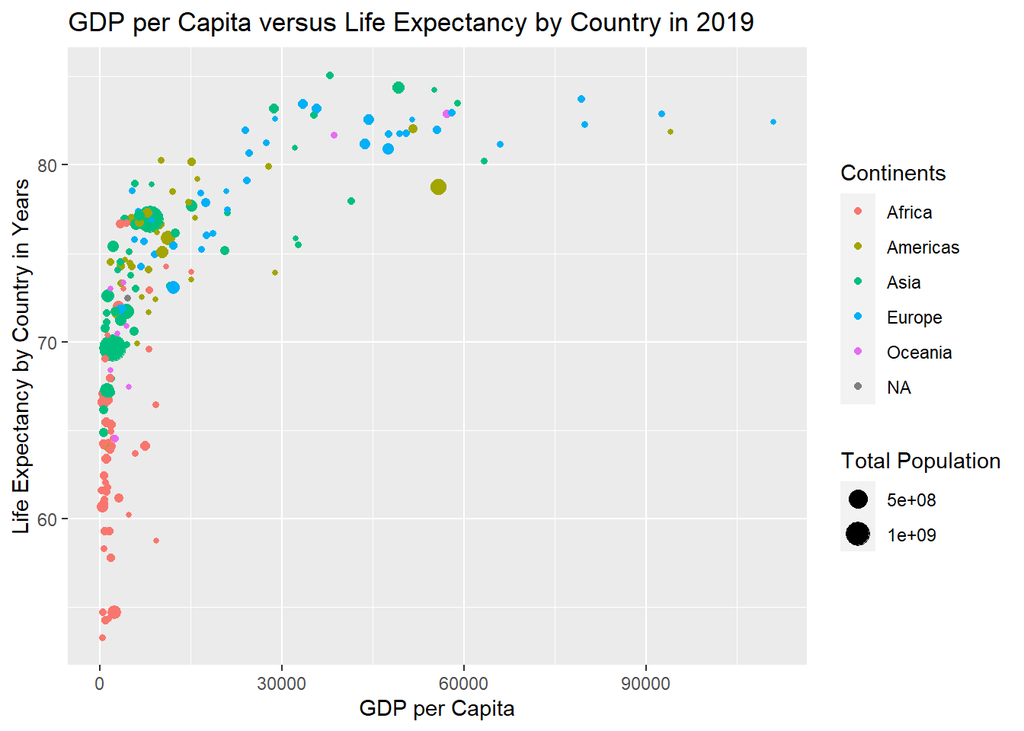

```r
data_2019 <- gapminder %>%
  filter(time == 2019) %>%
  filter(!is.na(GDP_PC) & !is.na(lifeExpectancy))

ggplot(data_2019, aes(x = GDP_PC, y = lifeExpectancy, size = totalPopulation)) +
    geom_point(aes(color = region)) +
    labs(x = "GDP per Capita", y = "Life Expectancy by Country in Years",
         color = "Continents", size = "Total Population") +
    ggtitle("GDP per Capita versus Life Expectancy by Country in 2019")
```

3. (6pt) Compare these two plots and comment what do you see. How has world developed through the last 60 years?

4. (6pt) Compute the average life expectancy for each continent in 1960 and 2019. Do the results fit with what do you see on the figures?  
   Note: here as *average*I mean just average over countries, ignore the fact that countries are of different size.

```r
avg_life_exp_in_1960_and_2016 <- gapminder %>%
  filter(!is.na(lifeExpectancy) & !is.na(region)) %>%
  filter(time == 1960 | time == 2016) %>%
  group_by(region, time) %>%
  summarize(avg_life_exp = mean(lifeExpectancy, na.rm = TRUE)) %>%
  print()
```

```
## # A tibble: 10 × 3
## # Groups:   region [5]
##    region    time avg_life_exp
##    <chr>    <dbl>        <dbl>
##  1 Africa    1960         41.5
##  2 Africa    2016         63.0
##  3 Americas  1960         58.6
##  4 Americas  2016         75.3
##  5 Asia      1960         51.6
##  6 Asia      2016         74.0
##  7 Europe    1960         68.3
##  8 Europe    2016         79.0
##  9 Oceania   1960         56.4
## 10 Oceania   2016         73.0
```

The result fits in the relationship in the figure, as developed countries in Oceania, Europe and Americas still have higher life expectancy, but developing countries in Africa and Asia are catching up quickly.

5. (8pt) Compute the average LE growth from 1960-2019 across the continents. Show the results in the order of growth. Explain what do you see.  
   Hint: these data (data in long form) is not the simplest to compute growth. But you may want to check out the lag() function. And do not forget to group data by continent when using lag(), otherwise your results will be messed up! See [**https://faculty.washington.edu/otoomet/info201-book/dplyr.html#dplyr-helpers-compute**](https://faculty.washington.edu/otoomet/info201-book/dplyr.html#dplyr-helpers-compute).

```r
avg_le_growth <- gapminder %>%
  filter(!is.na(lifeExpectancy) & !is.na(region)) %>%
  filter(time <= 2019 & time >= 1960) %>%
  group_by(region) %>%
  mutate(prev = lag(lifeExpectancy),
         growth = (lifeExpectancy - prev)) %>%
  summarize(avg_le_growth = mean(growth, na.rm = TRUE)) %>%
  arrange(avg_le_growth) %>%
  print()
```

```
## # A tibble: 5 × 2
##   region   avg_le_growth
##   <chr>            <dbl>
## 1 Oceania        0.00319
## 2 Europe         0.00404
## 3 Americas       0.00615
## 4 Africa         0.00745
## 5 Asia           0.0114
```

The average life expectancy growth is high in developing countries in Asia and Africa, and has a lower growth in developed countries in Oceania, Europe and Americas.

6. (6pt) Show the histogram of GDP per capita for years of 1960 and 2019. Try to put both histograms on the same graph, see how well you can do it!

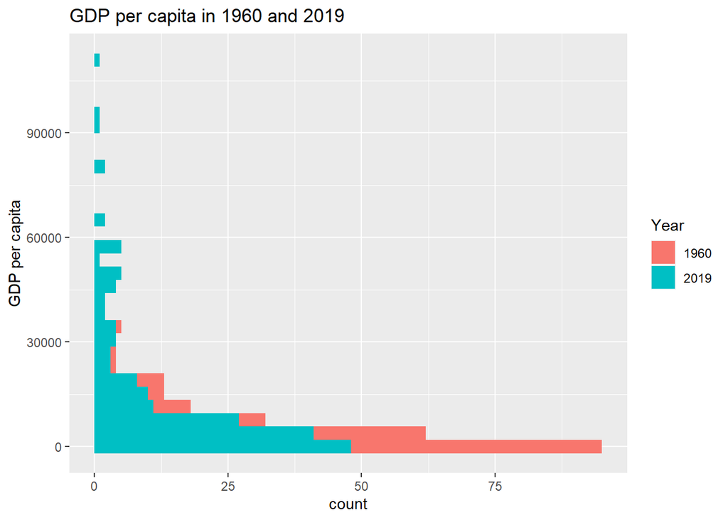

```r
GDP_PC_1960_to_2019 <- gapminder %>%
  filter(time == 1960 | time == 2019) %>%
  filter(!is.na(GDP_PC))

ggplot(GDP_PC_1960_to_2019, aes(y = GDP_PC)) +
  geom_histogram(aes(fill = factor(time))) +
  labs(title = "GDP per capita in 1960 and 2019", y = "GDP per capita", fill = "Year")
```

7. (6pt) What was the ranking of US in terms of life expectancy in 1960 and in 2019? (When counting from top.)  
   Hint: check out the function rank()!

```r
rank_in_1960 <- gapminder %>%
  filter(time == 1960) %>%
  arrange(desc(lifeExpectancy)) %>%
  mutate(rank_in_1960 = rank(-lifeExpectancy)) %>%
  filter(name == "United States of America") %>%
  select(rank_in_1960) %>%
  print()
```

```
## # A tibble: 1 × 1
##   rank_in_1960
##          <dbl>
## 1           18
```

```r
rank_in_1960 <- gapminder %>%
  filter(time == 2019) %>%
  arrange(desc(lifeExpectancy)) %>%
  mutate(rank_in_2019 = rank(-lifeExpectancy)) %>%
  filter(name == "United States of America") %>%
  select(rank_in_2019) %>%
  print()
```

```
## # A tibble: 1 × 1
##   rank_in_2019
##          <dbl>
## 1           47
```

8. (6pt) If you did this correctly, then you noticed that US ranking has been falling quite a bit. But we also have more countries in 2019–what about the relative rank divided by the corresponding number of countries that have LE data in the corresponding year?  
   Hint: 0.0904 for 1960.

```r
LE_in_1906_and_2019 <- gapminder %>%
  filter(!is.na(lifeExpectancy) & !is.na(region)) %>%
  filter(time == 1960 | time == 2019)
num_countries_1960 <- LE_in_1906_and_2019 %>%
  filter(time == 1960) %>%
  select(lifeExpectancy) %>%
  nrow()
num_countries_2019 <- LE_in_1906_and_2019 %>%
  filter(time == 2019) %>%
  select(lifeExpectancy) %>%
  nrow()
relative_rank_1960 <- 18 / num_countries_1960
relative_rank_2019 <- 47 / num_countries_2019
relative_rank_1960
```

```
## [1] 0.09574468
```

```r
relative_rank_2019
```

```
## [1] 0.2397959
```

The relative rank in 1960 was 0.0957, and 0.2398 in 2019.

Finally tell us how many hours did you spend on this PS.

6 hours